# jackie_lang_midterm

# 0 Github

## 0.1

Link to my github repository: https://github.com/jrlangberkeley/compscix-415-2-assignments

# 1 Tidyverse

## 1.1

1. *ggplot2* is the tidyverse package best tasked with plotting graphs. “ggplot2 is a system for declaratively creating graphics, based on The Grammar of Graphics. You provide the data, tell ggplot2 how to map variables to aesthetics, what graphical primitives to use, and it takes care of the details.” (citation: http://ggplot2.tidyverse.org/)
2. *dplyr* is the tidyverse package for data munging and wrangling. It “is a grammar of data manipulation, providing a consistent set of verbs that help you solve the most common data manipulation challenges.” (citation: http://dplyr.tidyverse.org/)
3. *tidyr* is the tidyverse package designed to assist with creating “tidy data.” It includes the functions to spread and gather data to reshape it to ensure that each variable is in a column, each observation is in a row, and each value is in a cell (citation: http://tidyr.tidyverse.org/)
4. *readr* is the tidyverse package for importing and exporting data. “The goal of readr is to provide a fast and friendly way to read rectangular data (like csv, tsv, and fwf). It is designed to flexibly parse many types of data found in the wild, while still cleanly failing when data unexpectedly changes.” (citation: http://readr.tidyverse.org/)

## 1.2

1. Two functions that I’ve used in the ggplot2 package are *aes()* to supply aestheic mapping data to the graph, including setting the parameters for the coordinates, and *geom_point()* which plots the data specified to a scatter plot.
2. Using the dplyr package, I’ve leveraged the *summarize()* and *filter()* functions to select and munge data. The summarize() funciton reduces multiple values down to a single value using statistics functions like mean, count (n()), and others. The filter() function returns rows with matching conditions. It evaluates whether conditions are true (binary), such as ==, >=, and !.
3. The tidyr package in the tidyverse contains two functions that I’ve used for reshaping and tidying data: the *gather()* and the *separate()* functions. The gather() function takes multiple values from separate columns and combines them, and the separate() funciton can take a single column and separate the values into separate columns which is extremely helpful for non-granular/non-atomic data.
4. For importing and exporting data using the readr package, I’ve used the *read_csv()* and *read_delim()* functions. Read_csv() is a more specific function than read_delim() which allows me to parse and read csv files specifically, which is very common in my line of work. Read_delim() has been helpful in other instances of files with a specific one character delimiter, like a pipe or semicolon. Again, this function also allows me to parse and read the file.

# 2 R Basics

## 2.1

original: My_data.name___is.too00ooLong! <- c( 1 , 2 , 3 ) should become:

```r
My_data.name___is.too00ooLong <- c(1, 2  , 3)
```

## 2.2

The two errors present in this string are the capital “C” in the concatenate function, and the missing single quote following “it” in the string of values to concatonate.

original: my_string <- C(‘has’, ‘an’, ‘error’, ‘in’, ’it) should become:

```r
my_string <- c('has', 'an', 'error', 'in', 'it')
```

## 2.3

All of the values placed in the vector were saved as characters because the values of “3” and “4” were called as characters rather than intergers when the code was written, as indicated by the single quotes surrounding these values. As I discovered, “adding a character string to a numeric vector converts all the elements in the vector to character” (citation: https://www.statmethods.net/management/typeconversion.html).

```r
my_vector <- c(1, 2, '3', '4', 5)
```

I tested this by using the function is.numeric() to test my_vector, and it is indeed false, indicating that the elements in the vector are indeed characters:

```r
is.numeric(my_vector)
```

```
## [1] FALSE
```

# Data import/export

## 3.1

Importing the file into R from my desktop. I used read_delim() because I observed the raw data and notied that it was a pipe delimited “|” file. This is the code to import the file:

```r
file_path <- 'C:/Users/jrlang/Desktop/rail_trail.txt'
delim_data <- read_delim((file = file_path), delim = "|")
```

And to glimpse the file:

```r
my_data <- delim_data
glimpse(my_data)
```

```
## Observations: 90
## Variables: 10
## $ hightemp   <int> 83, 73, 74, 95, 44, 69, 66, 66, 80, 79, 78, 65, 41,...
## $ lowtemp    <int> 50, 49, 52, 61, 52, 54, 39, 38, 55, 45, 55, 48, 49,...
## $ avgtemp    <dbl> 66.5, 61.0, 63.0, 78.0, 48.0, 61.5, 52.5, 52.0, 67....
## $ spring     <int> 0, 0, 1, 0, 1, 1, 1, 1, 0, 0, 0, 1, 1, 0, 0, 1, 0, ...
## $ summer     <int> 1, 1, 0, 1, 0, 0, 0, 0, 1, 1, 1, 0, 0, 0, 0, 0, 1, ...
## $ fall       <int> 0, 0, 0, 0, 0, 0, 0, 0, 0, 0, 0, 0, 0, 1, 1, 0, 0, ...
## $ cloudcover <dbl> 7.6, 6.3, 7.5, 2.6, 10.0, 6.6, 2.4, 0.0, 3.8, 4.1, ...
## $ precip     <dbl> 0.00, 0.29, 0.32, 0.00, 0.14, 0.02, 0.00, 0.00, 0.0...
## $ volume     <int> 501, 419, 397, 385, 200, 375, 417, 629, 533, 547, 4...
## $ weekday    <int> 1, 1, 1, 0, 1, 1, 1, 0, 0, 1, 1, 1, 1, 1, 1, 1, 0, ...
```

## 3.2

Exporting rail_trail.txt and converting it to an rds file:

```r
write_rds(delim_data, path = 'C:/Users/jrlang/Desktop/rail_trail.rds')
```

Reloading the newly transformed rail_trail.rds file: Importing rds file:

```r
file_path <- 'C:/Users/jrlang/Desktop/rail_trail.rds'
rail_trail <- readRDS(file = file_path, refhook = NULL)
```

Glimpse the .rds file in R studio as a tibble:

```r
as_tibble(rail_trail)
```

```
## # A tibble: 90 x 10
##    hightemp lowtemp avgtemp spring summer  fall cloudcover precip volume
##       <int>   <int>   <dbl>  <int>  <int> <int>      <dbl>  <dbl>  <int>
##  1       83      50    66.5      0      1     0       7.60 0         501
##  2       73      49    61.0      0      1     0       6.30 0.290     419
##  3       74      52    63.0      1      0     0       7.50 0.320     397
##  4       95      61    78.0      0      1     0       2.60 0         385
##  5       44      52    48.0      1      0     0      10.0  0.140     200
##  6       69      54    61.5      1      0     0       6.60 0.0200    375
##  7       66      39    52.5      1      0     0       2.40 0         417
##  8       66      38    52.0      1      0     0       0    0         629
##  9       80      55    67.5      0      1     0       3.80 0         533
## 10       79      45    62.0      0      1     0       4.10 0         547
## # ... with 80 more rows, and 1 more variable: weekday <int>
```

# 4 Visualization

## 4.2

See below for a recreation of the diamonds visualization:

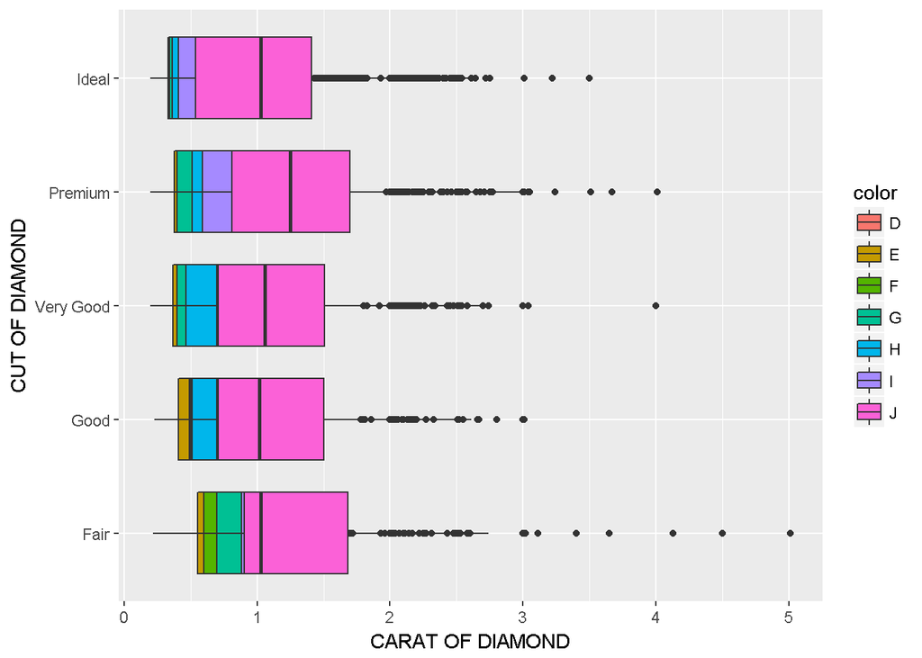

```r
ggplot(data = diamonds) +
geom_boxplot(aes(x = cut, y = carat, fill = color), position = position_dodge(0), width = 5) +
labs(x = "CUT OF DIAMOND", y = "CARAT OF DIAMOND") +
coord_flip()
```

## 4.3

I would change the graph so the boxplots are dodged by color, so I removed the function varwidth = TRUE. It makes the distribution of different colors more easily viewable for the reader. See below for the updated visualization:

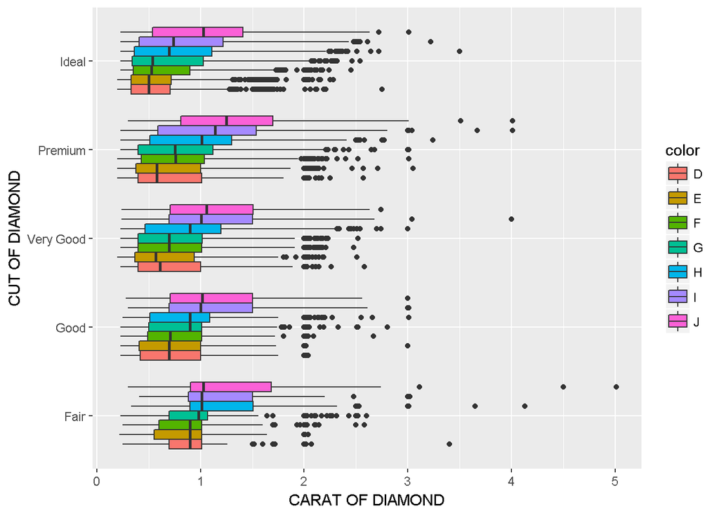

```r
ggplot(data = diamonds, mapping = aes(x = cut, y = carat, fill = color)) +
  geom_boxplot() + labs(x = "CUT OF DIAMOND", y = "CARAT OF DIAMOND") + coord_flip()
```

# 5 Data munging and wrangling

## 5.1

This table is not tidy, and to make it so I will separate the “cases” and “populations” values in the type column.

```r
spread(table2, key = type, value = count)
```

```
## # A tibble: 6 x 4
##   country      year  cases population
## * <chr>       <int>  <int>      <int>
## 1 Afghanistan  1999    745   19987071
## 2 Afghanistan  2000   2666   20595360
## 3 Brazil       1999  37737  172006362
## 4 Brazil       2000  80488  174504898
## 5 China        1999 212258 1272915272
## 6 China        2000 213766 1280428583
```

## 5.2

I first needed to create a column with the data for price per carat, which is the divided value from the price and carat columns:

```r
price_per_carat <- mutate(diamonds, price_per_carat = price/carat)
```

Then I needed to add the column to the diamonds tibble:

```r
diamonds <- price_per_carat
```

## 5.3

There are 834 instances of diamonds overall which are within the parameters of over 10000 and less than a carat weight of 1.5. This is 834/53,940 of the total number of instances in the original data set, accounting for about 1.55% of the overall dataset. I used the arithmetic feature in R to add up the totals of each cut and divided that by the total number of rows (instances) in the original dataset.

I selected to output the number of each cut, and the results are surprising. I’m surprised by the skewed distribution of the number of diamonds, especially the high number of ideal cuts in this set (over half of the total). It feels like there may be missing variables in this data set which help tell the story.

This leads into the other question, we may need to be wary of these numbers because they may only represent one retailer, one “cut” of diamond (for instance, round or emerald), or could be from a time or geographic area where diamonds were in particularly high demand. Another possibly exists that the diamonds from this set were from a dishonest distributor. There are a number of possible hidden variables in this dataset which could explain this subset.

```r
diamonds %>%
  filter(price > 10000, carat < 1.5) %>%
  group_by(cut) %>%
  count(cut)
```

```
## # A tibble: 5 x 2
## # Groups:   cut [5]
##   cut           n
##   <ord>     <int>
## 1 Fair          4
## 2 Good         17
## 3 Very Good   155
## 4 Premium     173
## 5 Ideal       485
```

# 6 EDA

## 6.1

Looking at the summary of this data, the time period represented in the txhousing dataset is between January 2000 to July 2015.

```r
summary(txhousing)
```

```
##      city                year          month            sales
##  Length:8602        Min.   :2000   Min.   : 1.000   Min.   :   6.0
##  Class :character   1st Qu.:2003   1st Qu.: 3.000   1st Qu.:  86.0
##  Mode  :character   Median :2007   Median : 6.000   Median : 169.0
##                     Mean   :2007   Mean   : 6.406   Mean   : 549.6
##                     3rd Qu.:2011   3rd Qu.: 9.000   3rd Qu.: 467.0
##                     Max.   :2015   Max.   :12.000   Max.   :8945.0
##                                                     NA's   :568
##      volume              median          listings       inventory
##  Min.   :8.350e+05   Min.   : 50000   Min.   :    0   Min.   : 0.000
##  1st Qu.:1.084e+07   1st Qu.:100000   1st Qu.:  682   1st Qu.: 4.900
##  Median :2.299e+07   Median :123800   Median : 1283   Median : 6.200
##  Mean   :1.069e+08   Mean   :128131   Mean   : 3217   Mean   : 7.175
##  3rd Qu.:7.512e+07   3rd Qu.:150000   3rd Qu.: 2954   3rd Qu.: 8.150
##  Max.   :2.568e+09   Max.   :304200   Max.   :43107   Max.   :55.900
##  NA's   :568         NA's   :616      NA's   :1424    NA's   :1467
##       date
##  Min.   :2000
##  1st Qu.:2004
##  Median :2008
##  Mean   :2008
##  3rd Qu.:2012
##  Max.   :2016
##
```

```r
txhousing %>%
  group_by(year, month) %>%
  arrange(desc(year))
```

```
## # A tibble: 8,602 x 9
## # Groups:   year, month [187]
##    city      year month sales   volume median listings inventory  date
##    <chr>    <int> <int> <dbl>    <dbl>  <dbl>    <dbl>     <dbl> <dbl>
##  1 Abilene   2015     1   158 23486998 134100      801      4.40  2015
##  2 Abilene   2015     2   151 19834263 126500      767      4.10  2015
##  3 Abilene   2015     3   198 31869437 136800      821      4.40  2015
##  4 Abilene   2015     4   201 28301159 129600      891      4.70  2015
##  5 Abilene   2015     5   199 31385757 144700      919      4.80  2015
##  6 Abilene   2015     6   260 41396230 141500      965      5.00  2015
##  7 Abilene   2015     7   268 45845730 148700      986      5.00  2016
##  8 Amarillo  2015     1   204 33188726 138500     1120      4.30  2015
##  9 Amarillo  2015     2   188 34355428 149400     1084      4.20  2015
## 10 Amarillo  2015     3   317 53603130 140900     1051      3.90  2015
## # ... with 8,592 more rows
```

## 6.2

There are 46 cities represented in this dataset.

```r
txhousing %>%
  count(city)
```

```
## # A tibble: 46 x 2
##    city                      n
##    <chr>                 <int>
##  1 Abilene                 187
##  2 Amarillo                187
##  3 Arlington               187
##  4 Austin                  187
##  5 Bay Area                187
##  6 Beaumont                187
##  7 Brazoria County         187
##  8 Brownsville             187
##  9 Bryan-College Station   187
## 10 Collin County           187
## # ... with 36 more rows
```

## 6.3

Houston had the highest number of sales at 8945 in July, 2015.

```r
txhousing %>%
  group_by(city, month, year) %>%
  arrange(desc(sales))
```

```
## # A tibble: 8,602 x 9
## # Groups:   city, month, year [8,602]
##    city     year month sales     volume median listings inventory  date
##    <chr>   <int> <int> <dbl>      <dbl>  <dbl>    <dbl>     <dbl> <dbl>
##  1 Houston  2015     7  8945 2568156780 217600    23875      3.40  2016
##  2 Houston  2006     6  8628 1795898108 155200    36281      5.60  2006
##  3 Houston  2013     7  8468 2168720825 187800    21497      3.30  2014
##  4 Houston  2015     6  8449 2490238594 222400    22311      3.20  2015
##  5 Houston  2013     5  8439 2121508529 186100    20526      3.30  2013
##  6 Houston  2014     6  8391 2342443127 211200    19725      2.90  2014
##  7 Houston  2014     7  8391 2278932511 199700    20214      3.00  2014
##  8 Houston  2014     8  8167 2195184825 202400    20007      2.90  2015
##  9 Houston  2013     8  8155 2083377894 186700    21366      3.30  2014
## 10 Houston  2006     5  8040 1602621368 151200    35398      5.50  2006
## # ... with 8,592 more rows
```

## 6.4

My assumption, just looking at the table of data arranged by descending sales (and using common sense), is that it would follow for there to be a positive relationship between the number of listings and the number of sales. I am not sure how strong the relationship would be due to the number of other variables associated with this question, but I would anticipate a relationship.

To check this assumption, I plotted the sales and listing data in a scatterplot. Based on the data, there is indeed positive relationship between the number of sales and the number of listings in this dataset. However, this only includes the instances where there was data available, and there could be a number of missing listings and sales, which would not be represented in this graph.

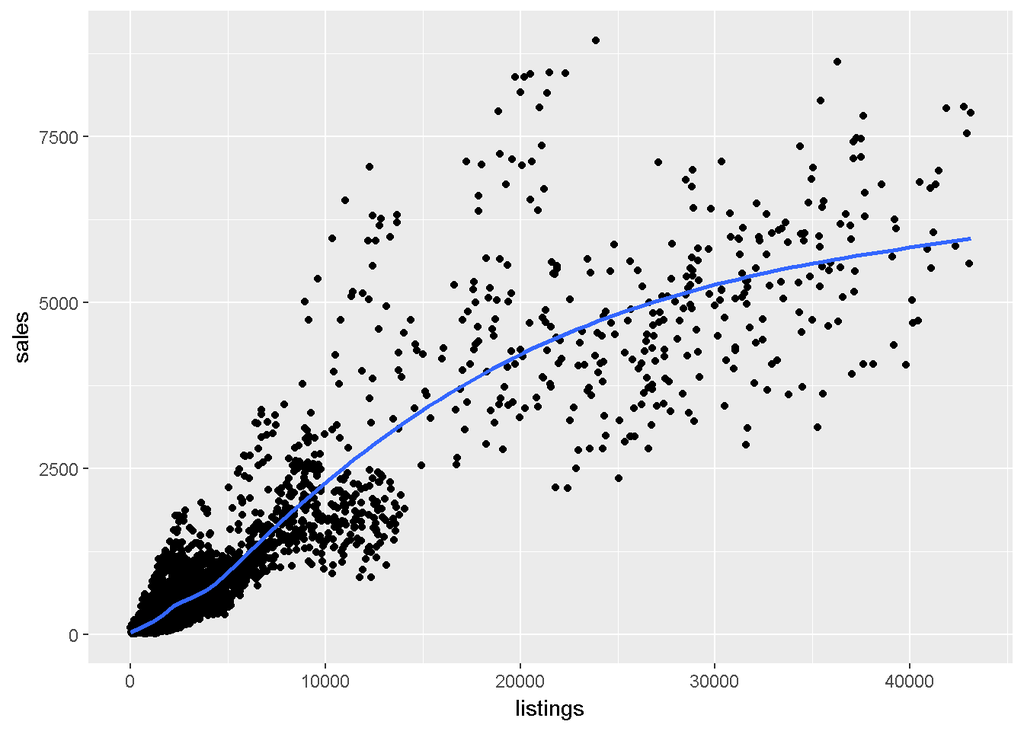

```r
txhousing %>%
  group_by(sales,listings) %>%
  arrange(desc(sales)) %>%
    ggplot(mapping = aes(x = listings, y = sales)) +
  geom_point(alpha = 1) +
  geom_smooth(se = FALSE)
```

## 6.5

```r
txhousing %>% mutate(miss_sales = (is.na(sales))) %>%
  group_by(city) %>%
            summarize(miss_sales = sum(is.na(sales)),
            n = n(),
            sum_miss_sales = sum(miss_sales, na.rm = TRUE),
            prop_sales = mean(miss_sales, na.rm = TRUE))
```

```
## # A tibble: 46 x 5
##    city                  miss_sales     n sum_miss_sales prop_sales
##    <chr>                      <int> <int>          <int>      <dbl>
##  1 Abilene                        0   187              0       0
##  2 Amarillo                       0   187              0       0
##  3 Arlington                      0   187              0       0
##  4 Austin                         0   187              0       0
##  5 Bay Area                       0   187              0       0
##  6 Beaumont                       0   187              0       0
##  7 Brazoria County               14   187             14      14.0
##  8 Brownsville                    2   187              2       2.00
##  9 Bryan-College Station          0   187              0       0
## 10 Collin County                  0   187              0       0
## # ... with 36 more rows
```

See the plot below for the graphical representation of the proportion of missed sales over the proportion on missed sales:

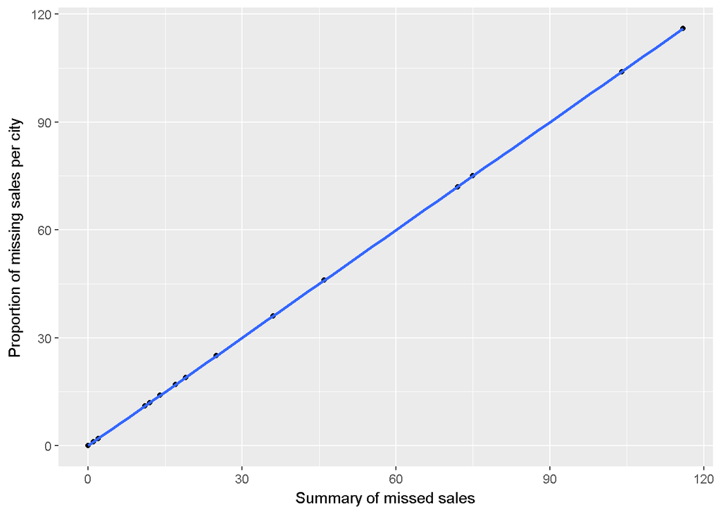

```r
txhousing %>% mutate(miss_sales = (is.na(sales))) %>%
  group_by(city) %>%
            summarize(miss_sales = sum(is.na(sales)),
            n = n(),
            sum_miss_sales = sum(miss_sales, na.rm = TRUE),
            prop_sales = mean(miss_sales, na.rm = TRUE)) %>%
    ggplot(mapping = aes(x = miss_sales, y = prop_sales), alpha = city) +
  geom_point(alpha = 1) +
  geom_smooth(se = FALSE) +
  xlab('Summary of missed sales') +
  ylab('Proportion of missing sales per city')
```

## 6.6

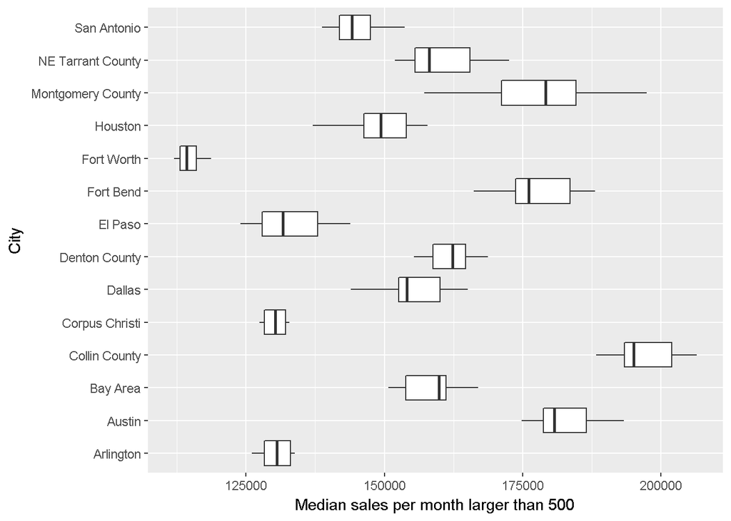

```r
txhousing %>%
  group_by(city, month) %>%
  filter(sales > 500) %>% summarize(med_sales = median(median, na.rm = TRUE)) %>%
  ggplot(aes(x = city, y = med_sales)) + coord_flip () +
  geom_boxplot() +
  ylab('Median sales per month larger than 500') +
  xlab('City')
```

To demonstrate this point, I created a graph for cities with sales less than 500 and a graph of the overall sales. It contains several outliers, and contains a much more variable overall distribution.

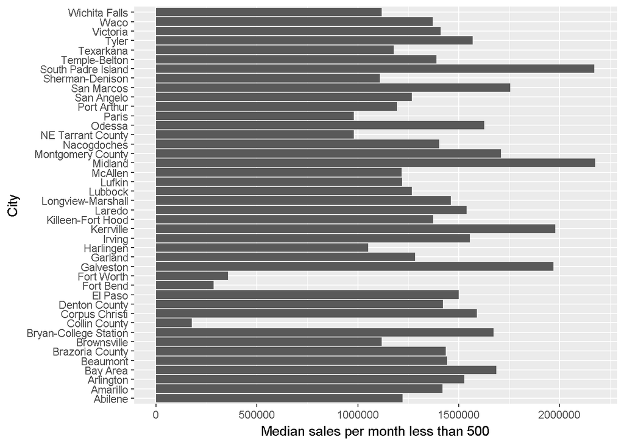

```r
txhousing %>%
  group_by(city, month) %>%
  filter(sales < 500) %>% summarize(med_sales = median(median, na.rm = TRUE)) %>%
  ggplot(aes(x = city, y = med_sales)) + coord_flip () +
  geom_bar(stat = "identity") +
  ylab('Median sales per month less than 500') +
  xlab('City')
```

Overall median sales distribution:

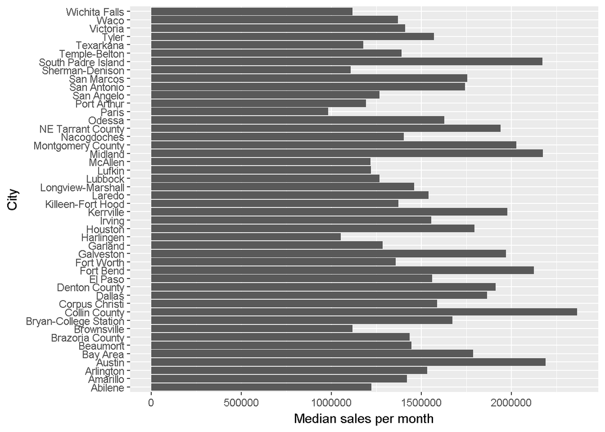

```r
txhousing %>%
  group_by(city, month) %>%
  summarize(med_sales = median(median, na.rm = TRUE)) %>%
  ggplot(aes(x = city, y = med_sales)) + coord_flip () +
  geom_bar(stat = "identity") +
  ylab('Median sales per month') +
  xlab('City')
```

# jackie_lang_midterm

# 0 Github

## 0.1

Link to my github repository: https://github.com/jrlangberkeley/compscix-415-2-assignments

# 1 Tidyverse

## 1.1

1. *ggplot2* is the tidyverse package best tasked with plotting graphs. “ggplot2 is a system for declaratively creating graphics, based on The Grammar of Graphics. You provide the data, tell ggplot2 how to map variables to aesthetics, what graphical primitives to use, and it takes care of the details.” (citation: http://ggplot2.tidyverse.org/)
2. *dplyr* is the tidyverse package for data munging and wrangling. It “is a grammar of data manipulation, providing a consistent set of verbs that help you solve the most common data manipulation challenges.” (citation: http://dplyr.tidyverse.org/)
3. *tidyr* is the tidyverse package designed to assist with creating “tidy data.” It includes the functions to spread and gather data to reshape it to ensure that each variable is in a column, each observation is in a row, and each value is in a cell (citation: http://tidyr.tidyverse.org/)
4. *readr* is the tidyverse package for importing and exporting data. “The goal of readr is to provide a fast and friendly way to read rectangular data (like csv, tsv, and fwf). It is designed to flexibly parse many types of data found in the wild, while still cleanly failing when data unexpectedly changes.” (citation: http://readr.tidyverse.org/)

## 1.2

1. Two functions that I’ve used in the ggplot2 package are *aes()* to supply aestheic mapping data to the graph, including setting the parameters for the coordinates, and *geom_point()* which plots the data specified to a scatter plot.
2. Using the dplyr package, I’ve leveraged the *summarize()* and *filter()* functions to select and munge data. The summarize() funciton reduces multiple values down to a single value using statistics functions like mean, count (n()), and others. The filter() function returns rows with matching conditions. It evaluates whether conditions are true (binary), such as ==, >=, and !.
3. The tidyr package in the tidyverse contains two functions that I’ve used for reshaping and tidying data: the *gather()* and the *separate()* functions. The gather() function takes multiple values from separate columns and combines them, and the separate() funciton can take a single column and separate the values into separate columns which is extremely helpful for non-granular/non-atomic data.
4. For importing and exporting data using the readr package, I’ve used the *read_csv()* and *read_delim()* functions. Read_csv() is a more specific function than read_delim() which allows me to parse and read csv files specifically, which is very common in my line of work. Read_delim() has been helpful in other instances of files with a specific one character delimiter, like a pipe or semicolon. Again, this function also allows me to parse and read the file.

# 2 R Basics

## 2.1

original: My_data.name___is.too00ooLong! <- c( 1 , 2 , 3 ) should become:

```r
My_data.name___is.too00ooLong <- c(1, 2  , 3)
```

## 2.2

The two errors present in this string are the capital “C” in the concatenate function, and the missing single quote following “it” in the string of values to concatonate.

original: my_string <- C(‘has’, ‘an’, ‘error’, ‘in’, ’it) should become:

```r
my_string <- c('has', 'an', 'error', 'in', 'it')
```

## 2.3

All of the values placed in the vector were saved as characters because the values of “3” and “4” were called as characters rather than intergers when the code was written, as indicated by the single quotes surrounding these values. As I discovered, “adding a character string to a numeric vector converts all the elements in the vector to character” (citation: https://www.statmethods.net/management/typeconversion.html).

```r
my_vector <- c(1, 2, '3', '4', 5)
```

I tested this by using the function is.numeric() to test my_vector, and it is indeed false, indicating that the elements in the vector are indeed characters:

```r
is.numeric(my_vector)
```

```
## [1] FALSE
```

# Data import/export

## 3.1

Importing the file into R from my desktop. I used read_delim() because I observed the raw data and notied that it was a pipe delimited “|” file. This is the code to import the file:

```r
file_path <- 'C:/Users/jrlang/Desktop/rail_trail.txt'
delim_data <- read_delim((file = file_path), delim = "|")
```

And to glimpse the file:

```r
my_data <- delim_data
glimpse(my_data)
```

```
## Observations: 90
## Variables: 10
## $ hightemp   <int> 83, 73, 74, 95, 44, 69, 66, 66, 80, 79, 78, 65, 41,...
## $ lowtemp    <int> 50, 49, 52, 61, 52, 54, 39, 38, 55, 45, 55, 48, 49,...
## $ avgtemp    <dbl> 66.5, 61.0, 63.0, 78.0, 48.0, 61.5, 52.5, 52.0, 67....
## $ spring     <int> 0, 0, 1, 0, 1, 1, 1, 1, 0, 0, 0, 1, 1, 0, 0, 1, 0, ...
## $ summer     <int> 1, 1, 0, 1, 0, 0, 0, 0, 1, 1, 1, 0, 0, 0, 0, 0, 1, ...
## $ fall       <int> 0, 0, 0, 0, 0, 0, 0, 0, 0, 0, 0, 0, 0, 1, 1, 0, 0, ...
## $ cloudcover <dbl> 7.6, 6.3, 7.5, 2.6, 10.0, 6.6, 2.4, 0.0, 3.8, 4.1, ...
## $ precip     <dbl> 0.00, 0.29, 0.32, 0.00, 0.14, 0.02, 0.00, 0.00, 0.0...
## $ volume     <int> 501, 419, 397, 385, 200, 375, 417, 629, 533, 547, 4...
## $ weekday    <int> 1, 1, 1, 0, 1, 1, 1, 0, 0, 1, 1, 1, 1, 1, 1, 1, 0, ...
```

## 3.2

Exporting rail_trail.txt and converting it to an rds file:

```r
write_rds(delim_data, path = 'C:/Users/jrlang/Desktop/rail_trail.rds')
```

Reloading the newly transformed rail_trail.rds file: Importing rds file:

```r
file_path <- 'C:/Users/jrlang/Desktop/rail_trail.rds'
rail_trail <- readRDS(file = file_path, refhook = NULL)
```

Glimpse the .rds file in R studio as a tibble:

```r
as_tibble(rail_trail)
```

```
## # A tibble: 90 x 10
##    hightemp lowtemp avgtemp spring summer  fall cloudcover precip volume
##       <int>   <int>   <dbl>  <int>  <int> <int>      <dbl>  <dbl>  <int>
##  1       83      50    66.5      0      1     0       7.60 0         501
##  2       73      49    61.0      0      1     0       6.30 0.290     419
##  3       74      52    63.0      1      0     0       7.50 0.320     397
##  4       95      61    78.0      0      1     0       2.60 0         385
##  5       44      52    48.0      1      0     0      10.0  0.140     200
##  6       69      54    61.5      1      0     0       6.60 0.0200    375
##  7       66      39    52.5      1      0     0       2.40 0         417
##  8       66      38    52.0      1      0     0       0    0         629
##  9       80      55    67.5      0      1     0       3.80 0         533
## 10       79      45    62.0      0      1     0       4.10 0         547
## # ... with 80 more rows, and 1 more variable: weekday <int>
```

# 4 Visualization

## 4.2

See below for a recreation of the diamonds visualization:

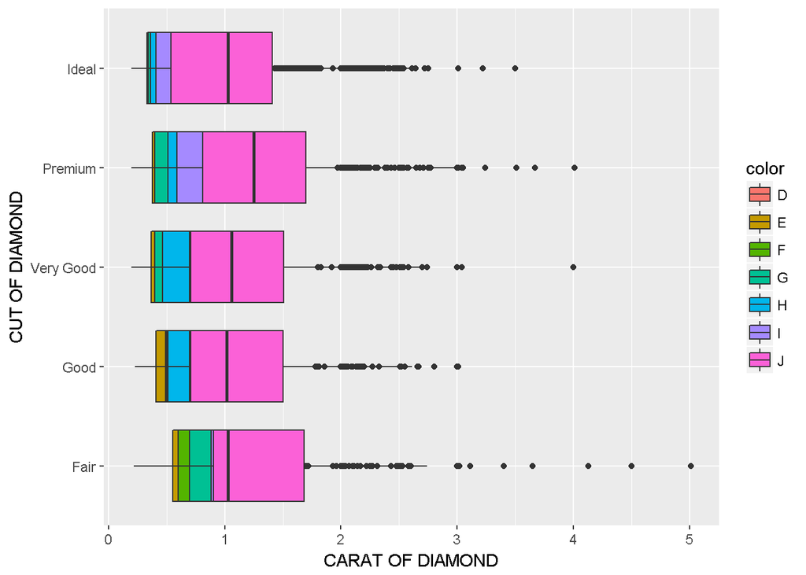

```r
ggplot(data = diamonds) +
geom_boxplot(aes(x = cut, y = carat, fill = color), position = position_dodge(0), width = 5) +
labs(x = "CUT OF DIAMOND", y = "CARAT OF DIAMOND") +
coord_flip()
```

## 4.3

I would change the graph so the boxplots are dodged by color, so I removed the function varwidth = TRUE. It makes the distribution of different colors more easily viewable for the reader. See below for the updated visualization:

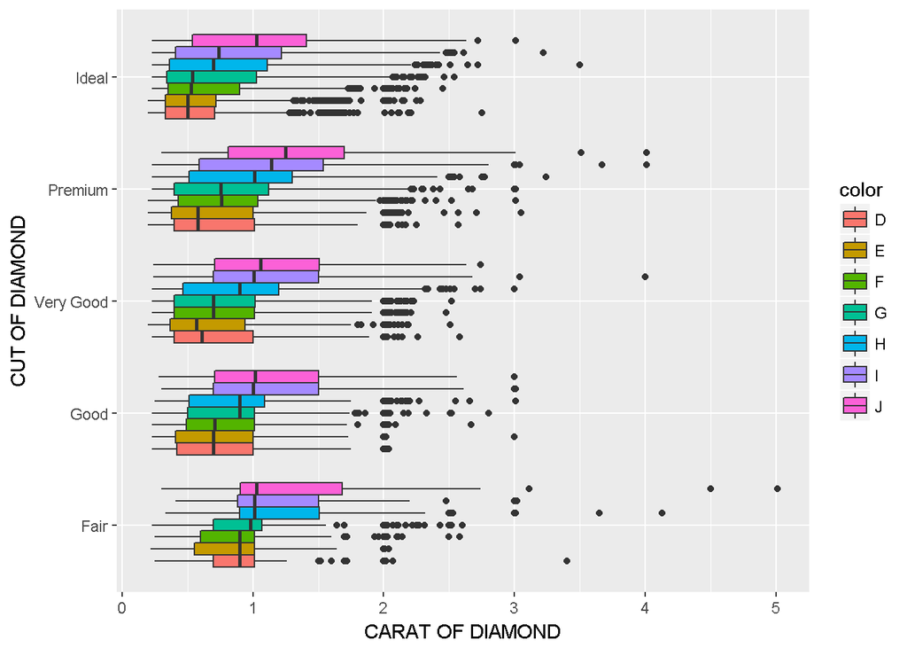

```r
ggplot(data = diamonds, mapping = aes(x = cut, y = carat, fill = color)) +
  geom_boxplot() + labs(x = "CUT OF DIAMOND", y = "CARAT OF DIAMOND") + coord_flip()
```

# 5 Data munging and wrangling

## 5.1

This table is not tidy, and to make it so I will separate the “cases” and “populations” values in the type column.

```r
spread(table2, key = type, value = count)
```

```
## # A tibble: 6 x 4
##   country      year  cases population
## * <chr>       <int>  <int>      <int>
## 1 Afghanistan  1999    745   19987071
## 2 Afghanistan  2000   2666   20595360
## 3 Brazil       1999  37737  172006362
## 4 Brazil       2000  80488  174504898
## 5 China        1999 212258 1272915272
## 6 China        2000 213766 1280428583
```

## 5.2

I first needed to create a column with the data for price per carat, which is the divided value from the price and carat columns:

```r
price_per_carat <- mutate(diamonds, price_per_carat = price/carat)
```

Then I needed to add the column to the diamonds tibble:

```r
diamonds <- price_per_carat
```

## 5.3

There are 834 instances of diamonds overall which are within the parameters of over 10000 and less than a carat weight of 1.5. This is 834/53,940 of the total number of instances in the original data set, accounting for about 1.55% of the overall dataset. I used the arithmetic feature in R to add up the totals of each cut and divided that by the total number of rows (instances) in the original dataset.

I selected to output the number of each cut, and the results are surprising. I’m surprised by the skewed distribution of the number of diamonds, especially the high number of ideal cuts in this set (over half of the total). It feels like there may be missing variables in this data set which help tell the story.

This leads into the other question, we may need to be wary of these numbers because they may only represent one retailer, one “cut” of diamond (for instance, round or emerald), or could be from a time or geographic area where diamonds were in particularly high demand. Another possibly exists that the diamonds from this set were from a dishonest distributor. There are a number of possible hidden variables in this dataset which could explain this subset.

```r
diamonds %>%
  filter(price > 10000, carat < 1.5) %>%
  group_by(cut) %>%
  count(cut)
```

```
## # A tibble: 5 x 2
## # Groups:   cut [5]
##   cut           n
##   <ord>     <int>
## 1 Fair          4
## 2 Good         17
## 3 Very Good   155
## 4 Premium     173
## 5 Ideal       485
```

# 6 EDA

## 6.1

Looking at the summary of this data, the time period represented in the txhousing dataset is between January 2000 to July 2015.

```r
summary(txhousing)
```

```
##      city                year          month            sales
##  Length:8602        Min.   :2000   Min.   : 1.000   Min.   :   6.0
##  Class :character   1st Qu.:2003   1st Qu.: 3.000   1st Qu.:  86.0
##  Mode  :character   Median :2007   Median : 6.000   Median : 169.0
##                     Mean   :2007   Mean   : 6.406   Mean   : 549.6
##                     3rd Qu.:2011   3rd Qu.: 9.000   3rd Qu.: 467.0
##                     Max.   :2015   Max.   :12.000   Max.   :8945.0
##                                                     NA's   :568
##      volume              median          listings       inventory
##  Min.   :8.350e+05   Min.   : 50000   Min.   :    0   Min.   : 0.000
##  1st Qu.:1.084e+07   1st Qu.:100000   1st Qu.:  682   1st Qu.: 4.900
##  Median :2.299e+07   Median :123800   Median : 1283   Median : 6.200
##  Mean   :1.069e+08   Mean   :128131   Mean   : 3217   Mean   : 7.175
##  3rd Qu.:7.512e+07   3rd Qu.:150000   3rd Qu.: 2954   3rd Qu.: 8.150
##  Max.   :2.568e+09   Max.   :304200   Max.   :43107   Max.   :55.900
##  NA's   :568         NA's   :616      NA's   :1424    NA's   :1467
##       date
##  Min.   :2000
##  1st Qu.:2004
##  Median :2008
##  Mean   :2008
##  3rd Qu.:2012
##  Max.   :2016
##
```

```r
txhousing %>%
  group_by(year, month) %>%
  arrange(desc(year))
```

```
## # A tibble: 8,602 x 9
## # Groups:   year, month [187]
##    city      year month sales   volume median listings inventory  date
##    <chr>    <int> <int> <dbl>    <dbl>  <dbl>    <dbl>     <dbl> <dbl>
##  1 Abilene   2015     1   158 23486998 134100      801      4.40  2015
##  2 Abilene   2015     2   151 19834263 126500      767      4.10  2015
##  3 Abilene   2015     3   198 31869437 136800      821      4.40  2015
##  4 Abilene   2015     4   201 28301159 129600      891      4.70  2015
##  5 Abilene   2015     5   199 31385757 144700      919      4.80  2015
##  6 Abilene   2015     6   260 41396230 141500      965      5.00  2015
##  7 Abilene   2015     7   268 45845730 148700      986      5.00  2016
##  8 Amarillo  2015     1   204 33188726 138500     1120      4.30  2015
##  9 Amarillo  2015     2   188 34355428 149400     1084      4.20  2015
## 10 Amarillo  2015     3   317 53603130 140900     1051      3.90  2015
## # ... with 8,592 more rows
```

## 6.2

There are 46 cities represented in this dataset.

```r
txhousing %>%
  count(city)
```

```
## # A tibble: 46 x 2
##    city                      n
##    <chr>                 <int>
##  1 Abilene                 187
##  2 Amarillo                187
##  3 Arlington               187
##  4 Austin                  187
##  5 Bay Area                187
##  6 Beaumont                187
##  7 Brazoria County         187
##  8 Brownsville             187
##  9 Bryan-College Station   187
## 10 Collin County           187
## # ... with 36 more rows
```

## 6.3

Houston had the highest number of sales at 8945 in July, 2015.

```r
txhousing %>%
  group_by(city, month, year) %>%
  arrange(desc(sales))
```

```
## # A tibble: 8,602 x 9
## # Groups:   city, month, year [8,602]
##    city     year month sales     volume median listings inventory  date
##    <chr>   <int> <int> <dbl>      <dbl>  <dbl>    <dbl>     <dbl> <dbl>
##  1 Houston  2015     7  8945 2568156780 217600    23875      3.40  2016
##  2 Houston  2006     6  8628 1795898108 155200    36281      5.60  2006
##  3 Houston  2013     7  8468 2168720825 187800    21497      3.30  2014
##  4 Houston  2015     6  8449 2490238594 222400    22311      3.20  2015
##  5 Houston  2013     5  8439 2121508529 186100    20526      3.30  2013
##  6 Houston  2014     6  8391 2342443127 211200    19725      2.90  2014
##  7 Houston  2014     7  8391 2278932511 199700    20214      3.00  2014
##  8 Houston  2014     8  8167 2195184825 202400    20007      2.90  2015
##  9 Houston  2013     8  8155 2083377894 186700    21366      3.30  2014
## 10 Houston  2006     5  8040 1602621368 151200    35398      5.50  2006
## # ... with 8,592 more rows
```

## 6.4

My assumption, just looking at the table of data arranged by descending sales (and using common sense), is that it would follow for there to be a positive relationship between the number of listings and the number of sales. I am not sure how strong the relationship would be due to the number of other variables associated with this question, but I would anticipate a relationship.

To check this assumption, I plotted the sales and listing data in a scatterplot. Based on the data, there is indeed positive relationship between the number of sales and the number of listings in this dataset. However, this only includes the instances where there was data available, and there could be a number of missing listings and sales, which would not be represented in this graph.

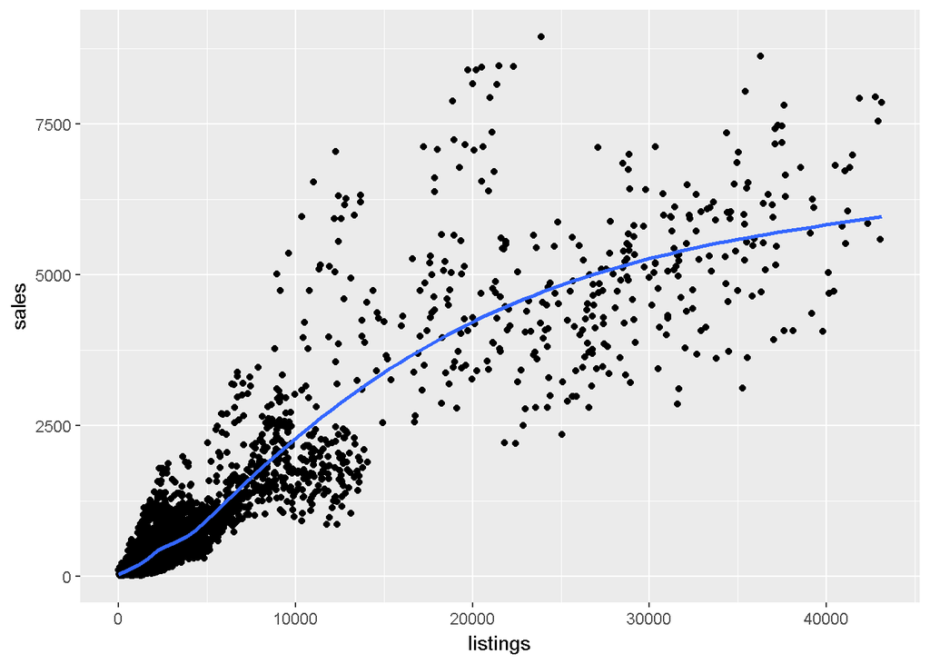

```r
txhousing %>%
  group_by(sales,listings) %>%
  arrange(desc(sales)) %>%
    ggplot(mapping = aes(x = listings, y = sales)) +
  geom_point(alpha = 1) +
  geom_smooth(se = FALSE)
```

## 6.5

```r
txhousing %>% mutate(miss_sales = (is.na(sales))) %>%
  group_by(city) %>%
            summarize(miss_sales = sum(is.na(sales)),
            n = n(),
            sum_miss_sales = sum(miss_sales, na.rm = TRUE),
            prop_sales = mean(miss_sales, na.rm = TRUE))
```

```
## # A tibble: 46 x 5
##    city                  miss_sales     n sum_miss_sales prop_sales
##    <chr>                      <int> <int>          <int>      <dbl>
##  1 Abilene                        0   187              0       0
##  2 Amarillo                       0   187              0       0
##  3 Arlington                      0   187              0       0
##  4 Austin                         0   187              0       0
##  5 Bay Area                       0   187              0       0
##  6 Beaumont                       0   187              0       0
##  7 Brazoria County               14   187             14      14.0
##  8 Brownsville                    2   187              2       2.00
##  9 Bryan-College Station          0   187              0       0
## 10 Collin County                  0   187              0       0
## # ... with 36 more rows
```

See the plot below for the graphical representation of the proportion of missed sales over the proportion on missed sales:

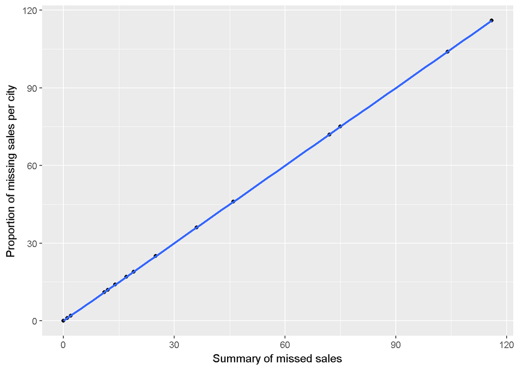

```r
txhousing %>% mutate(miss_sales = (is.na(sales))) %>%
  group_by(city) %>%
            summarize(miss_sales = sum(is.na(sales)),
            n = n(),
            sum_miss_sales = sum(miss_sales, na.rm = TRUE),
            prop_sales = mean(miss_sales, na.rm = TRUE)) %>%
    ggplot(mapping = aes(x = miss_sales, y = prop_sales), alpha = city) +
  geom_point(alpha = 1) +
  geom_smooth(se = FALSE) +
  xlab('Summary of missed sales') +
  ylab('Proportion of missing sales per city')
```

## 6.6

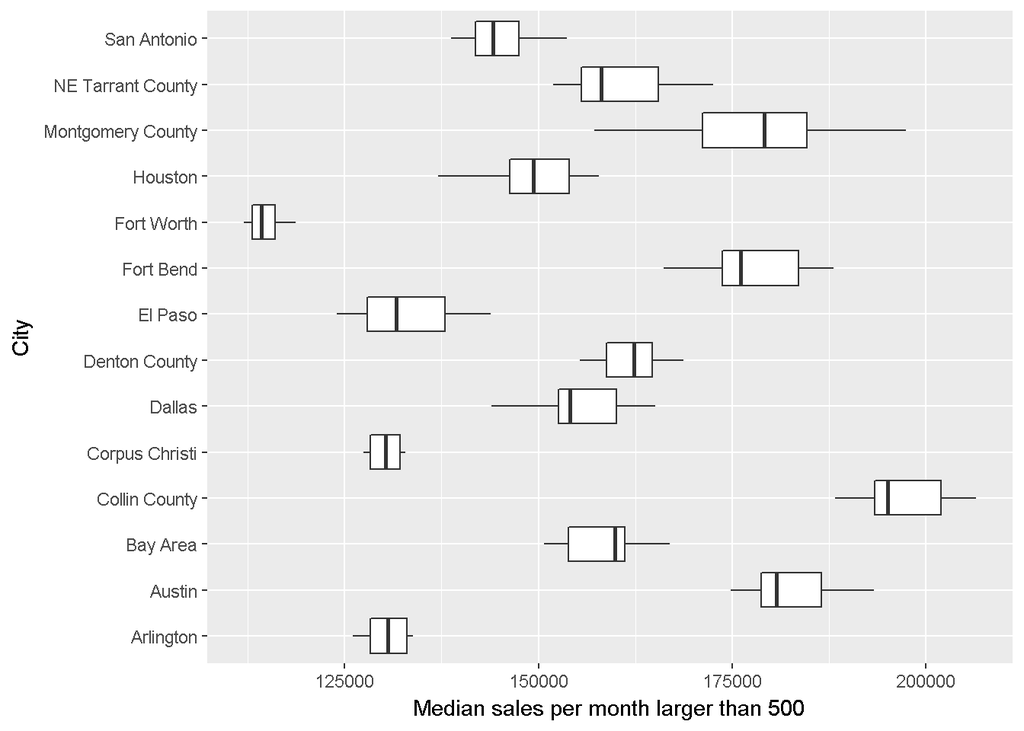

```r
txhousing %>%
  group_by(city, month) %>%
  filter(sales > 500) %>% summarize(med_sales = median(median, na.rm = TRUE)) %>%
  ggplot(aes(x = city, y = med_sales)) + coord_flip () +
  geom_boxplot() +
  ylab('Median sales per month larger than 500') +
  xlab('City')
```

To demonstrate this point, I created a graph for cities with sales less than 500 and a graph of the overall sales. It contains several outliers, and contains a much more variable overall distribution.

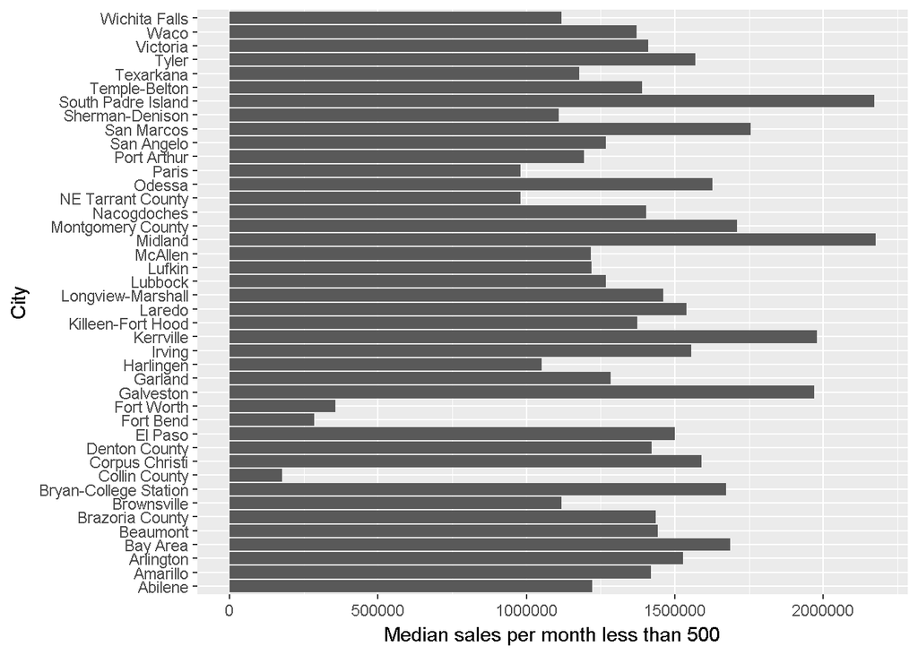

```r
txhousing %>%
  group_by(city, month) %>%
  filter(sales < 500) %>% summarize(med_sales = median(median, na.rm = TRUE)) %>%
  ggplot(aes(x = city, y = med_sales)) + coord_flip () +
  geom_bar(stat = "identity") +
  ylab('Median sales per month less than 500') +
  xlab('City')
```

Overall median sales distribution:

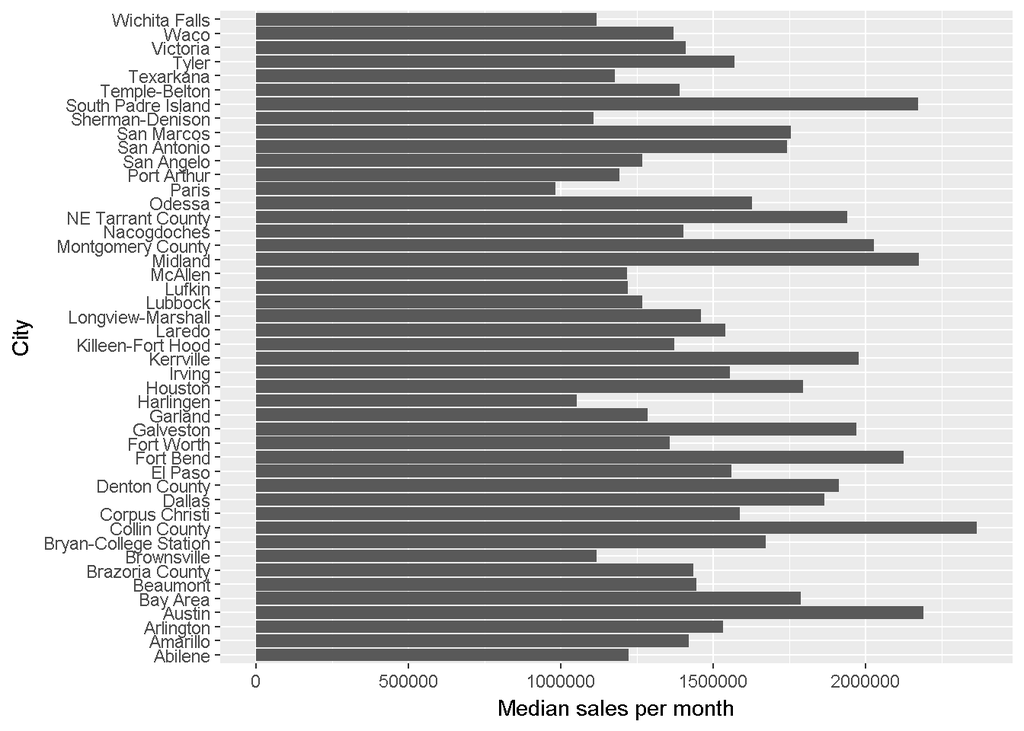

```r
txhousing %>%
  group_by(city, month) %>%
  summarize(med_sales = median(median, na.rm = TRUE)) %>%
  ggplot(aes(x = city, y = med_sales)) + coord_flip () +
  geom_bar(stat = "identity") +
  ylab('Median sales per month') +
  xlab('City')
```